# Avaliação Continuada - Aula 6

**Execute a célula a seguir para importar as bibliotecas de que vamos precisar e criar a variável `titanic` com nossa base de dados.**

```python
# Importando a biblioteca seaborn
import seaborn as sns
import matplotlib.pyplot as plt

# Carregando a base de dados 'titanic'
titanic = sns.load_dataset("titanic")

titanic.head()
```

|  | survived | pclass | sex | age | sibsp | parch | fare | embarked | class | who | adult_male | deck | embark_town | alive | alone |
| --- | --- | --- | --- | --- | --- | --- | --- | --- | --- | --- | --- | --- | --- | --- | --- |
| 0 | 0 | 3 | male | 22.0 | 1 | 0 | 7.2500 | S | Third | man | True | NaN | Southampton | no | False |
| 1 | 1 | 1 | female | 38.0 | 1 | 0 | 71.2833 | C | First | woman | False | C | Cherbourg | yes | False |
| 2 | 1 | 3 | female | 26.0 | 0 | 0 | 7.9250 | S | Third | woman | False | NaN | Southampton | yes | True |
| 3 | 1 | 1 | female | 35.0 | 1 | 0 | 53.1000 | S | First | woman | False | C | Southampton | yes | False |
| 4 | 0 | 3 | male | 35.0 | 0 | 0 | 8.0500 | S | Third | man | True | NaN | Southampton | no | True |

### Sobre os dados

No exercício de hoje, vamos utilizar as variáveis:

- `fare`: indica o valor pago pela passagem.
- `survived`: indica se o passageiro sobreviveu (`"1"`) ou não sobreviveu (`"0"`) ao afundamento do Titanic.

### Exercício de hoje - Parte 1

Utilize a função `sns.boxplot()` para criar um gráfico boxplot que mostre a distribuição de preços de passagem (coluna `"fare"`) pagos por passageiros que sobreviveram ou não ao acidente (coluna `"survived"`).

Coloque a variável que indica sobrevivência (coluna `"survived"`) no eixo X e a variável que indica o preço da passagem (coluna `"fare"`) no eixo Y.

Após escrever a linha de código de sua resposta, execute a célula para mostrar o gráfico a partir da base `titanic`.

**Importante: antes de executar o código da sua resposta, não deixe de executar a célula de código que está no início deste caderno, que importa as bibliotecas e carrega os dados.**

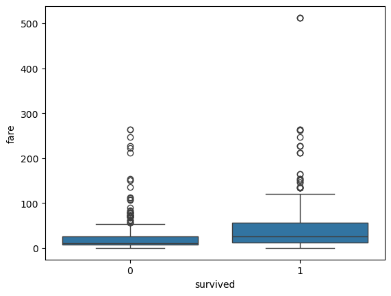

```python
# Escreva sua resposta abaixo e execute a célula para gerar o gráfico
sns.boxplot(
    x="survived", # nesse caso a escolha dos eixos não é livre: 'survived' deve vir no eixo x.
    y="fare",
    data=titanic
)
```

### Exercício de hoje - Parte 2

Parece que os passageiros que sobreviveram pagaram mais pela viagem! Para mostrar esse resultado interessante, produza novamente o mesmo gráfico, mas agora você deve customizá-lo da seguinte maneira:

- aumente o tamanho das dimensões do gráfico usando a função: `plt.subplots()` (uma sugestão é usar: `figsize=(10,6)`)
- adicione ao gráfico o seguinte título: `"Pay more for your ticket and you might survive the Titanic!"`,
- adicione ao eixo `x` o rótulo: `"Passenger survived the Titanic? (0 = No, 1 = Yes)"`.
- adicione ao eixo `y` o rótulo: `"Fare ($)"`.

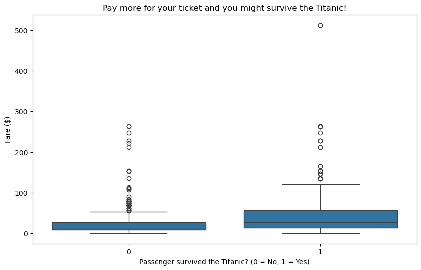

```python
# Escreva sua resposta abaixo e execute a célula para gerar o gráfico
fig, ax = plt.subplots(figsize=(10, 6)) # os valores de figsize podem ser diferentes

sns.boxplot(
    x="survived", # nesse caso a escolha dos eixos não é livre: 'survived' deve vir no eixo x.
    y="fare",
    data=titanic,
    ax=ax
)

ax.set_title("Pay more for your ticket and you might survive the Titanic!")
ax.set_xlabel("Passenger survived the Titanic? (0 = No, 1 = Yes)")
ax.set_ylabel("Fare ($)")

# se o aluno adicionar outras customizações (por exemplo cor), não há problema
```